# ACTSC 489 Interim Assessment - Frequency Model

Mary Sin Fai Lam (20696951)

22/02/2022

## Assumptions and data adjustments

Prior to the modelling process, we made the assumptions found on the case study outline found on Learn. Other assumptions and data adjustments made will be discussed throughout the report as we go through the modelling process.

## EDA on critical modelling variables

# EDA on response

| Comp_claim_count | record_count |
| --- | --- |
| 0 | 158693 |
| 1 | 2147 |
| 2 | 9 |

The response data seem reasonable, with the majority risks having no claim count given that auto claims are relatively rare. There are no negative or non-integer values, which is expected for a claim count variable. There is a small number risks having more than 1 claim and no extremely large values, and there is enough non-zero responses to build a reasonable model.

# EDA on exposure

Let’s check the minimum, median and maximum for the exposures:

```
##    0%   50%  100%
## 0.002 0.452 1.000
```

The exposures also seem reasonable with the lowest value being close to 0 (but not 0) and the highest value not exceeding 1 (as expected in 1 policy year). The overall distribution looks reasonable.

Checking the frequency distribution across different accident years, we see that there are some discrepancies in frequency, most likely attributed to trend over the years. We’ll account for that by introducing a temporal control variable in our models.

| Accident_year | exposure_total | numclaims_total | frequency |
| --- | --- | --- | --- |
| 2018 | 28013.26 | 716 | 0.02555932 |
| 2019 | 24917.28 | 916 | 0.03676164 |
| 2020 | 22278.20 | 533 | 0.02392473 |

Now, we start the modelling process by dividing our data into training and holdout set using a 70-30 split.

| partition | number_of_records | exposure_total | exposure_pct | numclaims_total | frequency |
| --- | --- | --- | --- | --- | --- |
| Holdout | 48091 | 22477.48 | 0.2988679 | 660 | 0.02936272 |
| Training | 112758 | 52731.27 | 0.7011321 | 1505 | 0.02854094 |

Following some validation, we can see that there is a 70-30 split of exposure between training and holdout and the frequency for both are similar, so there is no evidence of bias between the two.

# Marital Status

We start with GLM_initial, a glm fit with just the temporal control variable and our log(exposure) offset. Now, we want to add Marital status to our model, we’ll call it GLM1. We saw in Assignment 1 that there were many levels to Marital status that were not significant, and there were some missing values. We assign a new level: “Missing” to the missing values. Our exploratory data analysis that indicated that, aside from the “Married” and “Single” levels, most levels do not have a large amount of exposure. We should group based on the meaning of the levels, we assign “Married” to the levels Married, Same Sex, and Common Law, and “Single” otherwise.

We now perform a series of statistical tests, the results are summarised in the following table. Assessing **significance**, the p value is small for “Single”. It also seems **reasonable** to do so since it’s common in the insurance industry to use marital status as a rating variable. This is mostly because single drivers are usually younger and less experienced, thus are more likely to incur a claim. You can see claim frequency being higher for single drivers compared to their married counterpart in the appendix. For a **parsimony** check, AIC for GLM_initial was 15503 and decreases to 15493 for GLM1 and BIC increases from 15532 to 15541. The model passes AIC but fails BIC test. Performing a **time consistency** test, we fit an interaction between Marital_status and accident year in the model. The overall effect of Single and Missing levels, for each accident year, is obtained by aggregating the corresponding coefficients from this model. We find that “Single” is consistent across the the three years but “Missing” is not. However, this is not surprising due to low data volume in the “Missing” level. We are more concerned that the “Single” level passes the time consistency test since it has the most number of exposures anyway. Lastly, we perform an F test comparing GLM_initial with our nested model GLM1. The p value is 0.003797 and therefore significant. Following these tests, we conclude that adding Marital_status to our model increases its predictive power, and GLM1 becomes our best model so far.

|  | Coefficients | P-value | 2018 Effect | 2019 Effect | 2020 Effect |
| --- | --- | --- | --- | --- | --- |
| Marital_statusMissing | 0.371 | 0.140 | 0.661 | -0.286 | -9.853 |
| Marital_statusSingle | 0.190 | 0.002 | 0.246 | 0.115 | 0.248 |

# Insured age

We now wish to create a new variable which we suspect is a good predictor. We create the insured_age variable, which is the how old the insured is. We do so by subtracting the insured birth year from the year of the term effective date. Once created, we find that insured_age has missing values, however this is only for a small number of records and not accounting for a lot of exposures (see appendix for more details). Therefore, we decided to impute the missing values with the median insured age of 48. We also calculated the minimum and maximum value to validate our data:

```
##   0%  50% 100%
##   15   48   99
```

We can see that the minimum and maximum age seem reasonable, there aren’t any negative or extremely low/high values, although 99 seems a little old to be still driving! But let’s not make any additional modifications and visualize the data, we can see from the graph (in the appendix) that density for much older drivers is small, and density is concentrated at the median. Therefore, let’s add this variable to our GLM1, which we now call GLM2.

Similar to before, we perform our statistical tests, the results are summarised in the following table. Assessing **significance**, the p value is very small at 0.000127 for insured_age. From a **reasonability** standpoint, using age as a rating variable is reasonable and common in insurance, since usually younger drivers are less experienced, and thus more likely to incur a claim. You can see from the table below that the coefficient for insured_age is negative suggesting that claim frequency decreases as age increases, which is as expected. For the **parsimony** check, AIC for GLM1 was 15493 and decreases to 15476 for GLM2 and BIC also decreases from 15541 to 15534. Hence, the model passes both AIC and BIC test. Now, let’s perform a **time consistency** test, we fit an interaction between insured_age and accident year in the model. The overall effect of insured age, for each accident year, is obtained by aggregating the corresponding coefficients from this model. The results show that insured_age passes the time consistency check. Lastly, we perform an F test comparing GLM1 with GLM2. The p value is 0.0001133 and therefore very significant. Since insured_age passes all of our statistical tests, we keep it in our model, and GLM2 becomes our best model so far.

|  | Coefficients | P-value | 2018 Effect | 2019 Effect | 2020 Effect |
| --- | --- | --- | --- | --- | --- |
| insured_age_imputed | -0.008117 | 0.000127 | -0.013178 | -0.006446 | -0.009273 |

# Vehicle age

We now wish to create the vehicle_age variable, which is simply how old the vehicle is. We do so by subtracting the vehicle model year from the year of the term effective date. Once created, we find that vehicle_age is complete and has no missing values, so we do not modify the data further. Let’s validate our data by calculating the minimum, median and maximum value:

```
##   0%  50% 100%
##    2   10   65
```

The newest vehicle is two years old and the oldest 65 years old. The median is around 10. These numbers seem reasonable for vehicle age as there are no negative integers and no extreme high values. The distribution of the variable also seem reasonable, with a positively skewed distribution (see appendix).

We fit a new glm model (GLM3) with vehicle_age and the predictors from GLM2.

Let’s test our new model. The p value is extremely small (~0) for vehicle_age there it is very **significant**. From a **reasonability** standpoint, using vehicle age as a rating variable is reasonable and often used in insurance, we find that the coefficient is negative suggesting that the newer the vehicle, the more likely it is to incur a claim. This makes sense for comprehensive coverage, especially in the case of thefts, as newer vehicles are usually targeted. For the **parsimony** check, both AIC and BIC decreases, from 15476 to 15399 and 15534 to 15466, respectively. Hence, the model passes both AIC and BIC test. Now, let’s perform a **time consistency** test, this is done in the same way described above. The results show that vehicle_age is consistent across the three years. Lastly, we perform an F test comparing GLM2 with GLM3. The p value is almost 0 (8.863e-15) and therefore extremely significant. From our statistical tests, we include vehicle_age in our model and GLM3 is therefore our best model so far.

|  | Coefficients | P-value | 2018 Effect | 2019 Effect | 2020 Effect |
| --- | --- | --- | --- | --- | --- |
| vehicle_age | -0.042 | 2.67e-13 | -0.019 | -0.05 | -0.067 |

# Annual distance

Next, we’ll investigate whether Annual_distance makes a good predictor. There are some missing values, in this case we’ll impute those values with the median of 12000. For validation purposes, the minimum and maximum have also been calculated below:

```
##     0%    50%   100%
##      1  12000 310000
```

There are no negative values which is a good sign, however the minimum is 1 which is low but could be possible for vehicles that are rarely driven, e.g vintage collectible cars. Let’s keep those small values in for now. The maximum value also seems high. The graph of the distribution (in the appendix) can help us understand the data better:

The distribution is very right skewed, and annual distance reaches very large values but with low data volume. Considering right censoring at 35000, since density becomes very low after around this point (this affects 460 observations), we get the following graph:

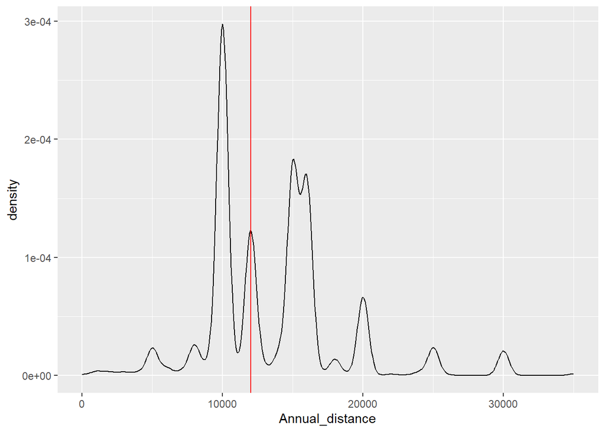

There are 3 noticeable spikes in the data, at 12000, which is expected since we replaced the missing values with the median 12000. There are spikes at 10000 and 15000, probably stemming from the fact that this variable is manually inputted by the policyholder, so they probably gave an round estimate of annual distance driven. Overall, the data seems to be valid.

The following graph shows the partial residuals by annual distance (capped at 35000):

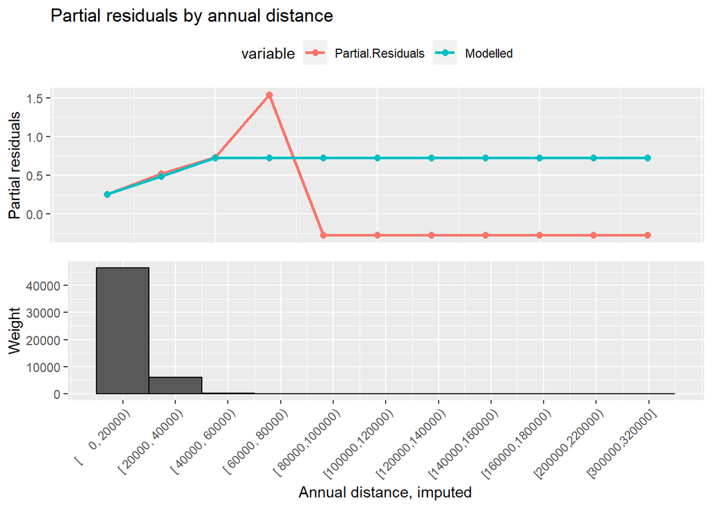

The model does fairly well for annual distance which is less than ~50000, probably due to higher data volumes for annual distances less than 50000. We see an obvious drop at around 75000, thereafter our model consistently overestimates our response. Let’s “zoom” in to see a more accurate picture, the following graph shows the partial residuals from [0,80000]:

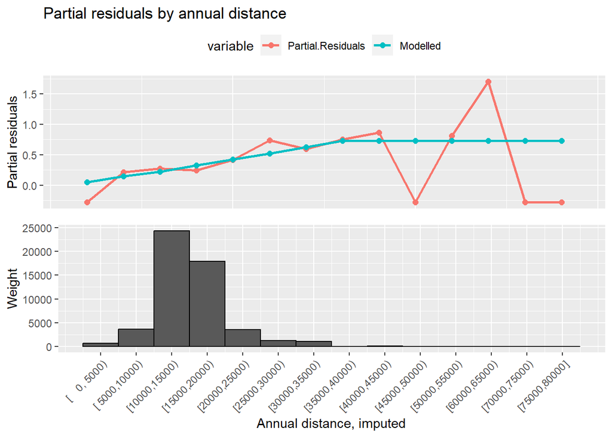

Our GLM4b model does fairly well for lower annual distances and seem to be picking up the signal quite well, there is some discrepancies where data volume becomes low but this is expected. However, we can see that after 75000, the model consistently overestimates our response (also seen in the earlier graph). We can try to introduce a hinge function at 75000. We do so by fitting another model, called GLM4c, this time with annual distance cap at 35000 and annual distance cap at 75000 added.

We checked the partial residuals graph, the hinge function reduces the distance between the modelled line and the partial residuals line but the model still slightly overfits the response (see appendix). We then compare the fit between model 4b and 4c using a **parsimony** test, we find that both AIC and BIC increase when we add the hinge function (GLM4c) from 15383.76 to 15385.49 and 15460.82 to 15472.19, respectively. The F test also suggest that GLM4b is a better fit with a p value of 0.657. Thus, so far our best model is GLM4b.